# HW1_Q5

## Logistic Regression

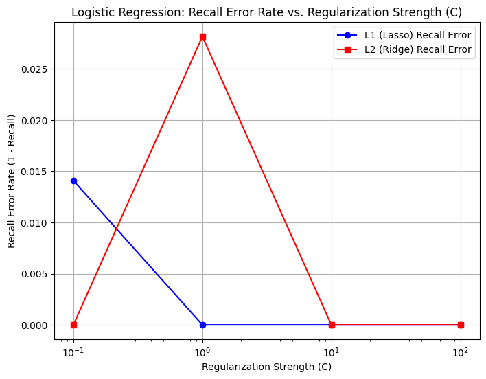

```python
import numpy as np
import matplotlib.pyplot as plt
from sklearn import linear_model
from sklearn.metrics import classification_report
from sklearn.model_selection import train_test_split
from sklearn.preprocessing import MinMaxScaler
from sklearn.datasets import load_breast_cancer

# Load dataset
data = load_breast_cancer()
X = data.data
y = data.target

# Ensure proper train-validation-test split before normalization
X_train, X_temp, y_train, y_temp = train_test_split(X, y, test_size=0.4, random_state=30, stratify=y)  # 60% train, 40% temp
X_val, X_test, y_val, y_test = train_test_split(X_temp, y_temp, test_size=0.5, random_state=30, stratify=y_temp)  # 20% val, 20% test

# Apply Min-Max Scaling (fit on training set, transform on validation & test sets)
scaler = MinMaxScaler()
X_train_minmax = scaler.fit_transform(X_train)
X_val_minmax = scaler.transform(X_val)
X_test_minmax = scaler.transform(X_test)

# Define C values for iteration
C_values = [100, 10, 1, 0.1]

# Store recall error rates
recall_errors_l1 = []
recall_errors_l2 = []

# Iterate through each C value and train both L1 and L2 regularization models
for C in C_values:
    clf_l1 = linear_model.LogisticRegression(C=C, penalty='l1', tol=0.01, solver='liblinear', max_iter=1000)
    clf_l2 = linear_model.LogisticRegression(C=C, penalty='l2', tol=0.01, solver='lbfgs', max_iter=1000)

    # Train the Models on Min-Max Normalized Training Data
    clf_l1.fit(X_train_minmax, y_train)
    clf_l2.fit(X_train_minmax, y_train)

    # Predictions on Validation Set
    y_val_pred_l1 = clf_l1.predict(X_val_minmax)
    y_val_pred_l2 = clf_l2.predict(X_val_minmax)

    # Compute Classification Reports
    report_l1 = classification_report(y_val, y_val_pred_l1, target_names=["Benign", "Malignant"], output_dict=True, zero_division=0)
    report_l2 = classification_report(y_val, y_val_pred_l2, target_names=["Benign", "Malignant"], output_dict=True, zero_division=0)

    recall_l1 = report_l1["Malignant"]["recall"]
    recall_l2 = report_l2["Malignant"]["recall"]

    # Store recall error rates (1 - recall)
    recall_errors_l1.append(1 - recall_l1)
    recall_errors_l2.append(1 - recall_l2)

# Plot Recall Error Rate vs. Regularization Strength (C)
plt.figure(figsize=(8, 6))
plt.plot(C_values, recall_errors_l1, marker='o', linestyle='-', color='b', label="L1 (Lasso) Recall Error")
plt.plot(C_values, recall_errors_l2, marker='s', linestyle='-', color='r', label="L2 (Ridge) Recall Error")
plt.xscale("log")  # Log scale for better visualization
plt.xlabel("Regularization Strength (C)")
plt.ylabel("Recall Error Rate (1 - Recall)")
plt.title("Logistic Regression: Recall Error Rate vs. Regularization Strength (C)")
plt.legend()
plt.grid(True)
plt.show()
```

Observations:

- For L1 (Lasso) regularization (blue line), recall error decreases as C increases, reaching zero at C=1.
- For L2 (Ridge) regularization (red line), recall error fluctuates, peaking at C=1 before dropping back to zero for larger C values.

L1 vs. L2 Regularization Performance:

- L1 (Lasso) maintains a decreasing recall error rate, indicating that it consistently improves as regularization is relaxed.
- L2 (Ridge) shows instability at C=1, with a sudden increase in recall error before stabilizing at C=10.

Conclusion:

- L1 regularization (Lasso) with C=1 appears to be the best choice, as it achieves a recall error of zero.
- L2 regularization (Ridge) may not be ideal due to its fluctuation in recall error, making it less reliable for recall-sensitive applications.

```python
from sklearn import linear_model
from sklearn.metrics import classification_report, confusion_matrix

# Define the best model (based on previous analysis, best C = 1, L1 regularization)
best_model = linear_model.LogisticRegression(C=1, penalty='l1', tol=0.01, solver='liblinear', max_iter=1000)

# Train on the full training set (train + validation)
X_full_train_minmax = np.concatenate((X_train_minmax, X_val_minmax), axis=0)
y_full_train = np.concatenate((y_train, y_val), axis=0)
best_model.fit(X_full_train_minmax, y_full_train)

# Predictions on Test Set (Fixing Variable Name)
y_test_pred = best_model.predict(X_test_minmax)  # Fixed variable name

# Print Classification Report
print("\n**Final Model Performance on Test Set**")
print(classification_report(y_test, y_test_pred, target_names=["Benign", "Malignant"], zero_division=1))
```

```
**Final Model Performance on Test Set**
              precision    recall  f1-score   support

      Benign       0.97      0.88      0.93        42
   Malignant       0.93      0.99      0.96        72

    accuracy                           0.95       114
   macro avg       0.95      0.93      0.94       114
weighted avg       0.95      0.95      0.95       114
```